# PA02 · Medio físico, ambiente y biodiversidad de un municipio dominicano Biogeografía Universidad Autónoma de Santo Domingo (UASD)

José-Ramón Martínez-Batlle

2026-09-08

# Fecha/hora de entrega

**VER PORTAL DE LA ASIGNATURA**

# Propósito de la práctica

En esta práctica estudiarás cómo cambia la **composición de la flora registrada** dentro de un municipio de la República Dominicana elegido por ti, y hasta qué punto esos patrones se asocian con el **medio físico, el clima, la cobertura del suelo, la heterogeneidad del paisaje y otras variables ambientales**. El trabajo combinará SIG, datos abiertos de biodiversidad, estadística multivariada y regresión.

Dentro del municipio, la unidad espacial principal será el **hexágono H3 de resolución 7**. Cada hexágono tiene una superficie media (calculada a nivel global) cercana a 5.16 km², aunque su superficie real varía con la posición geográfica. Cada hexágono H3 dispone de más de 140 variables ambientales calculadas para los fines; puedes obtener más información sobre ese dataset [aquí](https://github.com/geofis/zonal-statistics) (Martínez-Batlle, 2022). Los registros de GBIF no se interpretarán como un censo exhaustivo ni como abundancias: son **registros de presencia acumulados con intensidades de registro espacialmente desiguales**. Por ello, el número de registros por hexágono debe describirse y considerarse explícitamente al interpretar la riqueza observada. Por ello, **no se puede asumir que la ausencia de un registro signifique ausencia biológica, ni que un registro de presencia de una especie se corresponda con las condiciones actuales del hábitat**. Por otra parte, los registros de GBIF presentan otras limitaciones que debes reconocer: fueron obtenidos en fechas distintas, por personas distintas, con propósitos distintos y bajo criterios taxonómicos que pueden haber cambiado. Además, con datos de GBIF no podemos hablar de esfuerzo de muestreo, pero si podemos considerar los registros para realizar análisis de intensidad de registro.

El producto principal **no es un conjunto de mapas ni una colección de pruebas estadísticas aisladas: es un minimanuscrito científico** en el que una pregunta biogeográfica se responde mediante evidencia reproducible.

> **IMPORTANTE · IA bajo auditoría.** Puedes usar herramientas de inteligencia artificial como apoyo, tutor, depurador o interlocutor. Durante la defensa deberás identificar y demostrar **al menos un error, limitación, simplificación indebida o afirmación no verificada producida por una IA durante tu trabajo**. Conserva evidencia concreta y explica cómo verificaste o corregiste el problema. Si no utilizaste IA, decláralo explícitamente.

# Objetivos

Al finalizar la práctica deberás demostrar o mejorar tus capacidades para:

- formular una pregunta biogeográfica concreta sobre diversidad, composición o asociación especie–ambiente;
- visualizar y auditar datos de ocurrencia de biodiversidad en QGIS;
- comprender las limitaciones de los datos oportunistas de GBIF y distinguir **registros**, **presencias**, **riqueza observada** y **abundancia**;
- construir una matriz de comunidad de presencia/ausencia por hexágonos H3;
- construir una matriz ambiental coherente con las mismas unidades espaciales;
- seleccionar variables ambientales con criterio ecológico y reducir redundancia/colinealidad;
- explorar composición florística mediante ordenación multivariada;
- evaluar asociaciones entre composición y ambiente;
- analizar diferencias entre hábitats cuando el municipio tenga replicación suficiente;
- modelar riqueza observada mediante regresión considerando explícitamente la intensidad de registro (`n_registros`);
- identificar especies asociadas a tipos de hábitat cuando los datos lo permitan;
- comunicar resultados mediante mapas, figuras, tablas y un manuscrito reproducible;
- reconocer limitaciones de escala, sesgo de muestreo, calidad de coordenadas y cobertura taxonómica;
- auditar críticamente el uso de inteligencia artificial.

# Datos que usarás

Elige un municipio y, IMPORTANTE, anúncialo en el foro. Cada estudiante trabajará con **un municipio** asignado o elegido de los municipios candidatos mostrados en la Figura 1. El código de seis dígitos mostrado en el mapa corresponde al prefijo de la carpeta que contiene los datos del municipio; por ejemplo, `010901_moca` corresponde al municipio de Moca.

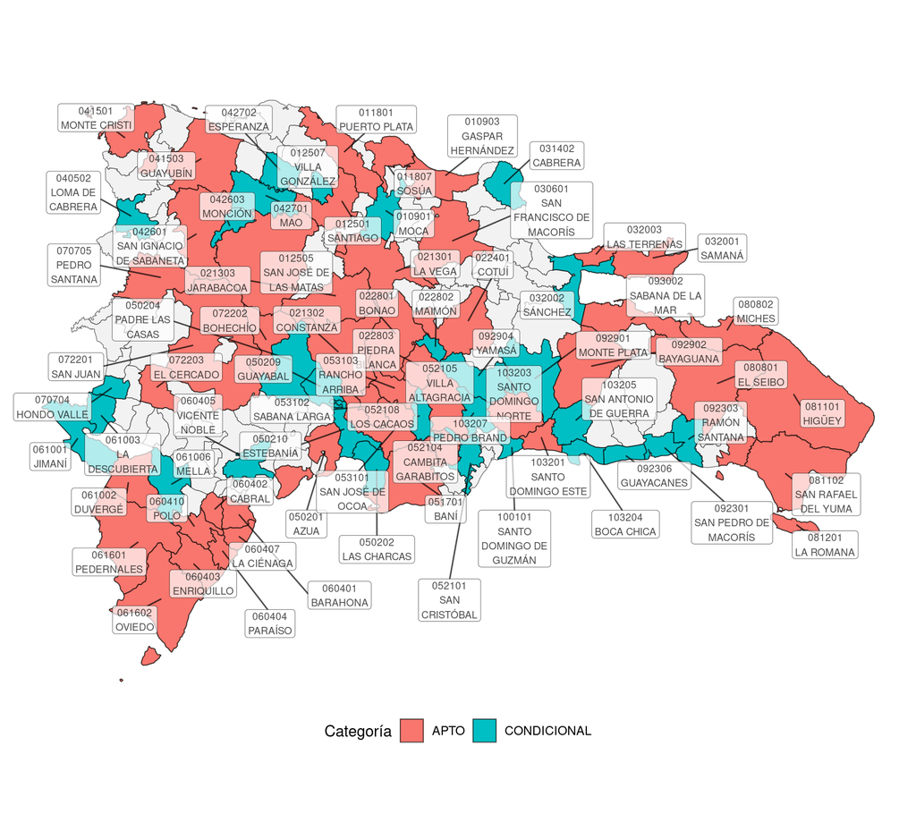

Figure 1: Municipios disponibles para la práctica. Se muestran los municipios clasificados como aptos o condicionales y el código utilizado para identificar su carpeta de datos.

## Municipios disponibles y características de los datos

La tabla siguiente resume algunas características de los municipios disponibles. Estas cifras permiten comparar la cantidad y distribución de la información antes de elegir. Las categorías **APTO** y **CONDICIONAL** indican si los datos cumplen los criterios operativos utilizados para recomendar el municipio; no constituyen una valoración de su importancia biogeográfica.

Table 1: Municipios disponibles y características generales de los datos de biodiversidad utilizados para evaluar su elegibilidad.

| Código | Municipio | Provincia | Registros | Especies | H3 con registros | H3 ≥5 spp. | Mediana registros/H3 | Especies en ≥3 H3 | Grupos de hábitat | Categoría |
| --- | --- | --- | --- | --- | --- | --- | --- | --- | --- | --- |
| 021302 | Constanza | 13 | 5583 | 1715 | 154 | 98 | 11.5 | 473 | 3 | APTO |
| 061601 | Pedernales | 16 | 4124 | 1340 | 178 | 101 | 8.0 | 308 | 4 | APTO |
| 021303 | Jarabacoa | 13 | 3451 | 1236 | 109 | 73 | 11.0 | 290 | 1 | APTO |
| 022801 | Bonao | 28 | 1873 | 972 | 90 | 40 | 4.0 | 79 | 1 | APTO |
| 061002 | Duvergé | 10 | 2163 | 861 | 76 | 50 | 11.5 | 142 | 4 | APTO |
| 053101 | San José De Ocoa | 31 | 1963 | 843 | 86 | 52 | 9.5 | 153 | 2 | APTO |
| 081101 | Higüey | 11 | 3316 | 774 | 175 | 86 | 5.0 | 223 | 5 | APTO |
| 012501 | Santiago | 25 | 2051 | 755 | 78 | 42 | 6.5 | 146 | 3 | APTO |
| 051701 | Baní | 17 | 1745 | 753 | 142 | 64 | 5.0 | 115 | 5 | APTO |
| 093002 | Sabana De La Mar | 30 | 1630 | 657 | 68 | 37 | 8.0 | 114 | 3 | APTO |
| 081102 | San Rafael Del Yuma | 11 | 1802 | 632 | 64 | 43 | 11.0 | 124 | 3 | APTO |
| 011801 | Puerto Plata | 18 | 1462 | 598 | 81 | 38 | 5.0 | 91 | 3 | APTO |
| 060407 | La Ciénaga | 04 | 1382 | 586 | 34 | 27 | 18.5 | 80 | 2 | APTO |
| 012505 | San José De Las Matas | 25 | 1071 | 583 | 154 | 57 | 3.0 | 65 | 2 | APTO |
| 053102 | Sabana Larga | 31 | 1408 | 568 | 32 | 21 | 12.5 | 67 | 1 | APTO |
| 060404 | Paraíso | 04 | 1007 | 529 | 32 | 24 | 14.0 | 50 | 1 | APTO |
| 032001 | Samaná | 20 | 1307 | 522 | 101 | 46 | 4.0 | 98 | 2 | APTO |
| 050201 | Azua | 02 | 947 | 513 | 53 | 24 | 3.0 | 48 | 3 | APTO |
| 060401 | Barahona | 04 | 729 | 491 | 38 | 22 | 11.5 | 25 | 2 | APTO |
| 103203 | Santo Domingo Norte | 32 | 1210 | 472 | 63 | 24 | 4.0 | 67 | 3 | APTO |
| 072203 | El Cercado | 22 | 808 | 456 | 29 | 20 | 10.0 | 26 | 2 | APTO |
| 011807 | Sosúa | 18 | 1160 | 453 | 57 | 30 | 5.0 | 102 | 2 | APTO |
| 042601 | San Ignacio De Sabaneta | 26 | 795 | 435 | 83 | 29 | 3.0 | 34 | 2 | APTO |
| 103201 | Santo Domingo Este | 32 | 875 | 433 | 50 | 23 | 5.0 | 47 | 4 | APTO |
| 060402 | Cabral | 04 | 702 | 423 | 23 | 16 | 11.0 | 17 | 1 | APTO |
| 021301 | La Vega | 13 | 572 | 382 | 77 | 27 | 2.0 | 17 | 4 | APTO |
| 060410 | Polo | 04 | 699 | 379 | 33 | 19 | 7.0 | 10 | 1 | APTO |
| 081201 | La Romana | 12 | 806 | 370 | 48 | 24 | 5.5 | 56 | 4 | APTO |
| 052104 | Cambita Garabitos | 21 | 650 | 370 | 36 | 20 | 8.0 | 22 | 1 | APTO |
| 053103 | Rancho Arriba | 31 | 675 | 366 | 39 | 20 | 5.0 | 26 | 1 | APTO |
| 072202 | Bohechío | 22 | 526 | 349 | 33 | 17 | 6.0 | 16 | 1 | APTO |
| 061602 | Oviedo | 16 | 765 | 322 | 83 | 33 | 4.0 | 51 | 5 | APTO |
| 072201 | San Juan | 22 | 439 | 319 | 70 | 18 | 2.0 | 6 | 4 | APTO |
| 032003 | Las Terrenas | 20 | 644 | 315 | 27 | 17 | 10.0 | 35 | 2 | APTO |
| 022803 | Piedra Blanca | 28 | 487 | 314 | 35 | 19 | 6.0 | 10 | 1 | APTO |
| 092902 | Bayaguana | 29 | 605 | 313 | 60 | 24 | 4.0 | 34 | 2 | APTO |
| 010903 | Gaspar Hernández | 09 | 610 | 313 | 39 | 18 | 4.0 | 27 | 3 | APTO |
| 080802 | Miches | 08 | 563 | 310 | 58 | 22 | 4.0 | 25 | 3 | APTO |
| 022401 | Cotuí | 24 | 477 | 301 | 46 | 17 | 3.0 | 26 | 2 | APTO |
| 030601 | San Francisco De Macorís | 06 | 560 | 289 | 69 | 22 | 3.0 | 35 | 3 | APTO |
| 052105 | Villa Altagracia | 21 | 487 | 259 | 53 | 18 | 4.0 | 15 | 2 | APTO |
| 041503 | Guayubín | 15 | 394 | 234 | 68 | 23 | 2.0 | 25 | 3 | APTO |
| 070705 | Pedro Santana | 07 | 335 | 233 | 34 | 16 | 3.0 | 6 | 2 | APTO |
| 060403 | Enriquillo | 04 | 317 | 229 | 35 | 15 | 4.0 | 5 | 1 | APTO |
| 080801 | El Seibo | 08 | 361 | 228 | 45 | 17 | 3.0 | 4 | 2 | APTO |
| 041501 | Monte Cristi | 15 | 456 | 213 | 50 | 17 | 3.0 | 24 | 6 | APTO |
| 100101 | Santo Domingo De Guzmán | 01 | 847 | 414 | 21 | 14 | 28.0 | 53 | 2 | CONDICIONAL |
| 061003 | La Descubierta | 10 | 650 | 385 | 25 | 14 | 9.0 | 7 | 3 | CONDICIONAL |
| 042702 | Esperanza | 27 | 646 | 377 | 26 | 9 | 2.0 | 8 | 2 | CONDICIONAL |
| 070704 | Hondo Valle | 07 | 739 | 362 | 21 | 12 | 8.0 | 18 | 2 | CONDICIONAL |
| 010901 | Moca | 09 | 411 | 243 | 54 | 14 | 2.0 | 17 | 1 | CONDICIONAL |
| 042603 | Monción | 26 | 374 | 233 | 24 | 12 | 7.0 | 9 | 1 | CONDICIONAL |
| 050204 | Padre Las Casas | 02 | 303 | 233 | 39 | 12 | 3.0 | 4 | 2 | CONDICIONAL |
| 050209 | Guayabal | 02 | 335 | 231 | 30 | 9 | 2.0 | 4 | 2 | CONDICIONAL |
| 060405 | Vicente Noble | 04 | 464 | 229 | 37 | 14 | 3.0 | 12 | 2 | CONDICIONAL |
| 103207 | Pedro Brand | 32 | 382 | 225 | 33 | 12 | 3.0 | 12 | 1 | CONDICIONAL |
| 092303 | Ramón Santana | 23 | 358 | 205 | 25 | 9 | 2.0 | 6 | 2 | CONDICIONAL |
| 103204 | Boca Chica | 32 | 341 | 200 | 22 | 10 | 6.0 | 6 | 3 | CONDICIONAL |
| 052101 | San Cristóbal | 21 | 289 | 195 | 37 | 12 | 3.0 | 6 | 2 | CONDICIONAL |
| 032002 | Sánchez | 20 | 282 | 194 | 36 | 14 | 3.5 | 8 | 3 | CONDICIONAL |
| 040502 | Loma De Cabrera | 05 | 262 | 186 | 28 | 11 | 2.5 | 3 | 2 | CONDICIONAL |
| 103205 | San Antonio De Guerra | 32 | 324 | 175 | 40 | 15 | 3.5 | 17 | 1 | CONDICIONAL |
| 012507 | Villa González | 25 | 232 | 173 | 13 | 9 | 8.0 | 1 | 1 | CONDICIONAL |
| 022802 | Maimón | 28 | 234 | 167 | 17 | 11 | 7.0 | 2 | 2 | CONDICIONAL |
| 061001 | Jimaní | 10 | 310 | 165 | 31 | 10 | 4.0 | 6 | 3 | CONDICIONAL |
| 092904 | Yamasá | 29 | 253 | 163 | 35 | 13 | 3.0 | 4 | 1 | CONDICIONAL |
| 050210 | Estebanía | 02 | 274 | 162 | 22 | 10 | 3.0 | 6 | 1 | CONDICIONAL |
| 031402 | Cabrera | 14 | 235 | 160 | 32 | 11 | 3.0 | 6 | 3 | CONDICIONAL |
| 050202 | Las Charcas | 02 | 281 | 155 | 37 | 13 | 3.0 | 10 | 3 | CONDICIONAL |
| 092901 | Monte Plata | 29 | 266 | 148 | 34 | 9 | 2.0 | 9 | 2 | CONDICIONAL |
| 092301 | San Pedro De Macorís | 23 | 240 | 144 | 22 | 11 | 4.5 | 7 | 4 | CONDICIONAL |
| 052108 | Los Cacaos | 21 | 249 | 141 | 21 | 10 | 4.0 | 4 | 1 | CONDICIONAL |
| 042701 | Mao | 27 | 172 | 140 | 33 | 10 | 2.0 | 3 | 1 | CONDICIONAL |
| 092306 | Guayacanes | 23 | 236 | 133 | 18 | 8 | 5.5 | 9 | 2 | CONDICIONAL |
| 061006 | Mella | 10 | 167 | 125 | 25 | 9 | 2.0 | 0 | 2 | CONDICIONAL |

Las columnas significan:

- **Registros:** número de registros de GBIF conservados para el municipio.
- **Especies:** riqueza total observada en los registros disponibles.
- **H3 con registros:** número de hexágonos H3 con al menos un registro.
- **H3 ≥5 spp.:** número de hexágonos con cinco o más especies registradas.
- **Mediana registros/H3:** mediana de la intensidad de registro entre los H3 con registros.
- **Especies en ≥3 H3:** especies registradas en al menos tres hexágonos.
- **Grupos de hábitat:** número de clases de hábitat con representación suficiente según el diagnóstico de elegibilidad.

Utiliza estas cifras para valorar qué municipio ofrece condiciones razonables para responder tu pregunta. **Un número mayor de registros o especies no implica automáticamente que un municipio sea mejor para cualquier pregunta biogeográfica.**

La lista de la tabla 1, que muestra los municipios elegibles y sus características de datos de diversidad de plantas, también la puedes ver directamente abriendo el archivo `00_resumen_elegibilidad_municipios.csv` del directorio mencionado (fíjate sólo en aquellos que tengan “APTO” o “CONDICIONAL” en la columna `categoria`).

Dentro del directorio `datos_por_municipio` del repo, fíjate en la lista de directorios, cada uno es un paquete de datos utilizable. El paquete de datos del municipio contendrá, como mínimo:

1. un polígono del municipio (formato GeoPackage);
2. registros de flora de GBIF ya sometidos a una limpieza espacial inicial (formato CSV);
3. hexágonos H3 de resolución 7 que intersectan el municipio, con unas 140 variables ambientales (formato GeoPackage);
4. un resumen de elegibilidad y cobertura de muestreo (formato CSV).

La limpieza inicial elimina o marca coordenadas inválidas, coordenadas problemáticas, registros próximos a centroides administrativos o instituciones de biodiversidad y puntos que no pueden asignarse espacialmente a un municipio dominicano, incluidos los situados fuera del territorio municipal o en el mar. Este proceso **no garantiza que todos los registros restantes sean correctos**. Debes continuar auditando visualmente tus datos.

Sólo para fines de registro y para tu conocimiento, el archivo fuente de GBIF que empleé para preparar los paquetes de datos por municipio que se encuentran en `datos_por_municipio/`, se llama `0003509-260715120105164.csv` (GBIF.org User, 2026). Dicho archivo, por su gran tamaño, **no se distribuyó en este repositorio**. Sin embargo, en tu manuscrito, debes referir dicha fuente GBIF usando la entrada BibTeX correspondiente.

# Entregables

Debes generar **tres productos obligatorios**.

## 1. Manuscrito reproducible

Entrega un manuscrito breve generado desde **RMarkdown**, usando como punto de partida `plantilla.Rmd`. El archivo fuente `.Rmd`, el PDF final, `bibliografia.bib` y el código necesario deben encontrarse en tu repositorio.

**Extensión sugerida:** 6–10 páginas, sin contar referencias ni material suplementario.

El manuscrito debe contener, como mínimo:

- título y título corto;
- autor/a;
- resumen y palabras clave;
- introducción;
- materiales y métodos;
- resultados;
- discusión;
- conclusiones;
- referencias;
- declaración breve de reproducibilidad;
- nota breve de auditoría de IA.

Puedes desarrollar los análisis en `analisis/00_cuaderno_trabajo_estudiante.Rmd`, ampliándolo, modificándolo o adaptándolo a tus necesidades, aunque dicho cuaderno no es un producto entregable. No olvides que el manuscrito final se redactará a partir de `plantilla.Rmd`, el cual sí es un producto entregable. Esto debo remarcarlo: **no uses el cuaderno de análisis como referente, porque no contiene todos los análisis que se pueden hacer en ecología numérica; es sólo un punto de partida para que desarrolles tus ideas y experimentes con los datos**.

## 2. Diapositivas

Prepara una presentación breve, preferentemente de **8–10 diapositivas**, centrada en la pregunta, los datos, el flujo de análisis, la evidencia principal, las limitaciones y la interpretación biogeográfica.

## 3. Defensa oral

Realizarás una defensa oral de **7 minutos**. Debes poder explicar qué representan tus datos, cómo construiste las matrices, por qué elegiste tus variables, qué significa tu ordenación, cómo trataste la intensidad de registro y qué limitaciones impiden interpretar los resultados como un inventario completo de la flora municipal.

# Mandato

## 1. Formula una pregunta biogeográfica

No basta con “hacer un NMDS” o “hacer mapas de GBIF”. Debes formular preguntas que puedan responderse con evidencia. Te incluyo algunas preguntas de **ejemplo**; podrás escoger todas las que quieras, pero debes incluir un mínimo de dos interrelacionadas entre sí.

1. **¿Qué gradientes ambientales se asocian con las principales diferencias de composición florística entre los H3 del municipio?** Es probablemente la pregunta más general para NMDS + `envfit`.
2. **¿La composición florística cambia a lo largo de un gradiente altitudinal dentro del municipio?** Muy apropiada para municipios con relieve suficiente.
3. **¿La composición florística se relaciona más estrechamente con variables climáticas o con variables del relieve?** Permite comparar grupos de predictores sin necesidad de meter las ~140 variables.
4. **¿Qué variables ambientales se asocian más fuertemente con la riqueza observada de plantas entre H3?**
5. **¿Se mantiene la asociación entre riqueza observada y ambiente después de considerar la intensidad de registro de GBIF?** Esta me gusta especialmente porque obliga a comprender el problema de `n_registros`.
6. **¿Cómo varían conjuntamente la riqueza observada y la intensidad de registro a través del municipio, y qué parte del patrón espacial de riqueza podría estar condicionada por esta última?** Más enfocada en sesgo espacial.
7. **¿La cobertura arbórea se asocia con diferencias en riqueza y composición florística entre H3?**
8. **¿Los H3 con mayor presencia de superficies agrícolas o construidas presentan una composición florística diferente de los H3 menos transformados?**
9. **¿La distancia a infraestructuras se relaciona con la riqueza observada o con la composición de las especies registradas?** Interesante aprovechando `OSM-DIST`, aunque requiere mucha cautela interpretativa porque también puede reflejar accesibilidad y, por tanto, intensidad de registro.
10. **¿La heterogeneidad ambiental o del paisaje se asocia con una mayor riqueza observada de plantas?**
11. **¿La composición florística difiere entre los principales tipos de cobertura o hábitat representados en el municipio?** Sólo si hay replicación suficiente.
12. **¿Qué especies presentan asociaciones estadísticas con los principales tipos de hábitat del municipio?** Igualmente condicionada a que existan grupos adecuados.
13. **¿Los sectores ambientalmente extremos del municipio albergan conjuntos de especies diferentes de los sectores con condiciones ambientales intermedias?** Requiere que el estudiante defina qué entiende por extremo de manera reproducible.
14. **¿Existen sectores del municipio que sean florísticamente semejantes pese a encontrarse espacialmente separados, y qué condiciones ambientales comparten?** Esta aprovecha muy bien el NMDS y obliga a pensar biogeográficamente.
15. **¿Coinciden los principales gradientes de variación florística con los principales gradientes ambientales del municipio?** Es sencilla de formular pero permite una discusión bastante rica.

Las preguntas anteriores son sólo **ejemplos o puntos de partida**. Puedes modificarlas o formular otras que sean compatibles con los datos disponibles en tu municipio. Igualmente, las preguntas deben ser concretas, responderse mediante las unidades H3 disponibles y conducir a objetivos e hipótesis o expectativas razonadas coherentes. Por otra parte, las hipótesis, el objetivo general y los específicos, deben ser coherentes y deben abarcar todas las preguntas formuladas, pero evita convertir la práctica en un proyecto de investigación semestral.

Te incluyo a continuación un **ejemplo de coherencia entre preguntas, objetivo e hipótesis**. Supongamos que se plantean las preguntas «¿La composición florística cambia a lo largo de un gradiente altitudinal dentro del municipio?» y «¿Qué variables ambientales se asocian con las principales diferencias de composición florística entre los H3 del municipio?». Un objetivo general coherente podría ser «Evaluar la asociación entre la variación ambiental, particularmente el gradiente altitudinal, y la composición florística registrada entre los H3 del municipio». Como hipótesis, podría plantearse que los H3 situados a elevaciones y bajo condiciones ambientales semejantes presentarán composiciones florísticas más similares entre sí que aquellos sometidos a condiciones contrastantes.

**Comprueba primero que tu municipio permite responder la pregunta.** Las preguntas sobre gradientes altitudinales requieren variación altitudinal suficiente; una comparación entre hábitats requiere varios hábitats con replicación; y una pregunta sobre urbanización, agricultura o cobertura arbórea requiere que esas variables presenten variación dentro del municipio. La disponibilidad de una variable en el GeoPackage no garantiza que sea informativa dentro de tu área de estudio.

Reitero que las preguntas elegidas deben estar relacionadas entre sí y contribuir a un planteamiento común; **no deben convertirse en dos investigaciones independientes reunidas artificialmente en un mismo manuscrito**. A partir de ellas, formula un objetivo general y, cuando sea necesario, objetivos específicos e hipótesis o expectativas razonadas que mantengan una correspondencia clara con las preguntas. **No copies este ejemplo como planteamiento de tu estudio:** formula los tuyos de acuerdo con el municipio, los datos disponibles y la literatura que consultes.

## 2. Reconoce la unidad de análisis

El registro individual de GBIF **no será la unidad estadística principal**. La unidad será el **hexágono H3 res. 7**. Para cada hexágono construirás:

- una fila de la matriz de comunidad;
- una fila de la matriz ambiental;
- una estimación de riqueza observada;
- una medida de intensidad de registro (`n_registros`);
- una clase de hábitat/cobertura cuando proceda.

No interpretes el número de registros de una especie como abundancia biológica. Para los análisis de composición usarás principalmente **presencia/ausencia**.

## 3. Primera etapa obligatoria: exploración en QGIS

Antes de entrar a R, crea un proyecto de QGIS y representa:

- el límite municipal;
- los registros de GBIF;
- la malla H3;
- la riqueza observada y/o número de registros por H3, cuando ya la hayas calculado;
- **al menos tres variables ambientales** de familias distintas: una climática, una de relieve y una de cobertura/uso o influencia humana.

Comprueba visualmente puntos en la costa, límites municipales, concentraciones anómalas y zonas sin registros. Los mapas que se incluyan en el manuscrito deben ser **composiciones cartográficas exportadas**, no capturas de pantalla de la interfaz de QGIS.

## 4. Construye y depura la matriz de comunidad

A partir de los registros limpios del municipio:

1. identifica la columna taxonómica que representa la especie aceptada;
2. elimina registros que no puedan asignarse a especie;
3. asigna cada registro a un `hex_id`;
4. reduce duplicados a **presencia/ausencia especie × hexágono**;
5. construye una matriz con hexágonos en filas y especies en columnas;
6. elimina especies excesivamente raras y hexágonos demasiado pobres sólo mediante un criterio declarado y justificado.

Como punto de partida puedes usar **especies presentes en ≥3 hexágonos** y **hexágonos con ≥5 especies**, pero esos valores no son una ley. Informa cuántos hexágonos y especies se pierden con el filtro y evalúa si sigue existiendo información suficiente.

## 5. Construye una matriz ambiental manejable

El GeoPackage H3 contiene unas 140 variables. **No debes introducirlas todas en un análisis sólo porque están disponibles.** Selecciona inicialmente entre **6 y 12 variables** que representen procesos o dimensiones ambientales distintas, por ejemplo:

- temperatura;
- precipitación;
- elevación;
- pendiente/rugosidad/posición topográfica;
- porcentaje de cobertura arbórea;
- agricultura o superficie construida;
- heterogeneidad del paisaje;
- distancia a infraestructura o presión humana, si su significado está documentado.

Después:

- elimina variables constantes o casi constantes dentro de tu municipio;
- inspecciona distribuciones y valores ausentes;
- revisa correlaciones entre variables;
- evita mantener predictores fuertemente redundantes en un mismo modelo;
- estandariza variables continuas antes de ordenaciones o comparaciones multivariadas cuando sea necesario.

**Debes documentar el significado y las unidades de cada variable elegida.** Los prefijos del GeoPackage orientan sobre la fuente, pero no sustituyen la consulta de los metadatos de la fuente original.

## 6. Describe el sesgo y la intensidad de registro

Genera, como mínimo:

- número de registros limpios;
- riqueza total observada;
- número de hexágonos con registros;
- distribución de registros por hexágono;
- distribución de riqueza por hexágono;
- relación entre riqueza observada y número de registros.

Si riqueza e intensidad de registro están fuertemente asociados, esto **no invalida** automáticamente el análisis, pero limita la interpretación y obliga a incorporar la intensidad de registro en la regresión y en la discusión.

## 7. Ordenación multivariada de la composición

Realiza una ordenación **NMDS** usando la matriz de presencia/ausencia y una disimilitud apropiada para datos binarios, por ejemplo Jaccard. Debes:

- informar la dimensión (`k`), el número de intentos y el estrés;
- examinar el gráfico de estrés/convergencia;
- representar los hexágonos en el espacio de ordenación;
- ajustar las variables ambientales seleccionadas mediante `envfit` u otra técnica equivalente;
- interpretar direcciones y asociaciones sin convertir correlación en causalidad.

Si el NMDS es inestable o tiene estrés inaceptable, debes diagnosticar el problema: pocos sitios, demasiados ceros compartidos, especies excesivamente raras o estructura insuficiente.

## 8. Diferencias de composición entre hábitats

Define una variable de hábitat a partir de la cobertura dominante u otra clasificación ecológicamente defendible. Si existen **al menos dos grupos con replicación suficiente**, evalúa si la composición difiere entre hábitats mediante PERMANOVA (`adonis2`) o método equivalente.

Antes de interpretar una PERMANOVA, evalúa la dispersión multivariada (`betadisper`). Una diferencia significativa entre grupos puede reflejar diferencias de centroides, diferencias de dispersión o ambas.

Si tu municipio no contiene suficientes tipos de hábitat o alguno tiene muy pocos hexágonos, **no fuerces la prueba**. Puedes justificar una reclasificación más gruesa o reportar que el diseño no permite esa comparación.

## 9. Regresión: riqueza observada y ambiente

Construye al menos **un modelo de regresión** en el que la respuesta sea la riqueza observada por H3. El modelo debe considerar explícitamente `n_registros` como intensidad de registro o, a lo sumo, como proxy del esfuerzo de muestreo —con mucha cautela en esta interpretación—, mediante una transformación, término funcional o estrategia estadística que puedas justificar. No asumas automáticamente que la relación entre número de registros y riqueza observada es lineal. El modelo debe incluir:

- `log1p(n_registros)` o una medida equivalente de la “intensidad de registro” o “proxy del esfuerzo de muestreo”;
- un conjunto pequeño de predictores ambientales no redundantes;
- una familia/distribución coherente con la respuesta y los residuos.

Una opción sencilla es comenzar con Poisson, evaluar sobredispersión y, si existe, utilizar un modelo binomial negativo o cuasi-Poisson. No selecciones variables únicamente por su valor *p*. La interpretación debe apoyarse en el signo, magnitud, incertidumbre y plausibilidad ecológica del efecto.

## 10. Asociación de especies con hábitat

Cuando existan grupos de hábitat adecuados, utiliza un análisis de especies indicadoras, por ejemplo `indicspecies::multipatt`, para evaluar qué especies muestran asociación con uno o varios tipos de hábitat.

Debes distinguir entre:

- una especie frecuente;
- una especie exclusiva;
- una especie indicadora;
- una asociación estadística con el agrupamiento usado.

No presentes como “indicadora ecológica” una especie sólo porque apareció una vez en un hábitat.

## 11. Integra los resultados

La ordenación, la regresión y la asociación con hábitat **no son tres tareas independientes**. En el manuscrito debes integrarlas para responder una misma pregunta o conjunto pequeño de preguntas relacionadas. Si realizaste otros análisis además de los mencionados, este es el lugar para incluir sus resultados, sin olvidar detallarlos en la sección “Materiales y métodos”.

# Reglas mínimas del análisis

1. pregunta explícita e hipótesis/expectativa razonada;
2. proyecto QGIS con exploración espacial documentada;
3. matriz de comunidad reproducible;
4. matriz ambiental con selección de variables justificada;
5. descripción de la intensidad de registro (número de puntos de registros de GBIF, traducido a veces, con “licencia”, como “ocurrencias”);
6. NMDS + ajuste ambiental;
7. regresión de riqueza con control de intensidad de registro;
8. evaluación explícita de si los datos permiten comparar hábitats y, cuando exista replicación suficiente, PERMANOVA + diagnóstico de dispersión;
9. evaluación explícita de si los datos permiten analizar asociaciones de especies con hábitats y, cuando proceda, análisis de especies indicadoras;
10. **mínimo 3 figuras científicas**, al menos una cartográfica y una multivariada;
11. **mínimo 2 tablas** generadas reproduciblemente;
12. al menos **4 resultados cuantitativos** escritos en el texto;
13. rutas relativas y código ejecutable;
14. CRS, escala H3, filtros y criterios documentados;
15. discusión explícita del sesgo de GBIF y de las limitaciones de inferencia.

# Flujo de trabajo recomendado

Antes de comenzar, ten en cuenta que el repositorio contiene dos archivos con funciones diferentes:

- `analisis/00_cuaderno_trabajo_estudiante.Rmd`: úsalo como **cuaderno de trabajo** para explorar los datos, construir matrices, probar análisis, generar diagnósticos y desarrollar el código. Puedes modificarlo libremente y añadir tantos bloques como necesites.
- `plantilla.Rmd`: úsala para redactar el **manuscrito científico final**. No conviertas el manuscrito en una transcripción del cuaderno de trabajo: selecciona e integra en él únicamente el código, las figuras, las tablas y los resultados necesarios para responder tu(s) pregunta(s).

El cuaderno de trabajo puede ser extenso y contener ensayos, comprobaciones y resultados intermedios. El manuscrito, en cambio, debe ser una narración científica concisa.

## Etapa 1 — Explorar y formular

- abre el paquete municipal en QGIS;
- inspecciona distribución de registros y variables;
- busca bibliografía sobre flora, ambientes y biogeografía de la región;
- formula pregunta e hipótesis.

## Etapa 2 — Preparar matrices

- importa registros y H3 en R;
- genera tabla especie–H3;
- genera matriz de presencia/ausencia;
- genera matriz ambiental en el mismo orden de H3;
- calcula riqueza e intensidad de registro;
- verifica que las filas de ambas matrices coincidan exactamente.

## Etapa 3 — Explorar y reducir variables

- estadísticas descriptivas;
- histogramas/densidades;
- mapa de variables clave;
- matriz de correlación;
- selección final de predictores.

## Etapa 4 — Analizar

- NMDS de composición;
- `envfit`;
- PERMANOVA y `betadisper`, si procede;
- regresión de riqueza;
- especies indicadoras, si procede.

## Etapa 5 — Verificar e interpretar

- comprueba supuestos y diagnósticos;
- vuelve al mapa para interpretar valores extremos;
- evalúa sensibilidad a filtros de especies/hexágonos;
- distingue señal ecológica de señal de muestreo.

## Etapa 6 — Redactar

Redacta el minimanuscrito usando `plantilla.Rmd`. El texto debe poder leerse sin necesidad de abrir la consola de R.

# Estructura del manuscrito

## Introducción

Extensión orientativa: **3–5 párrafos**. Debe presentar el problema, justificar por qué el ambiente puede estructurar la biodiversidad a escala intramunicipal, reconocer el carácter oportunista de GBIF y terminar con pregunta, objetivo e hipótesis.

## Materiales y métodos

Debe incluir:

- municipio y contexto espacial;
- procedencia y limpieza de GBIF;
- H3 resolución 7 como unidad espacial;
- fuentes/familias de variables ambientales;
- construcción y filtrado de la matriz de comunidad;
- selección y estandarización de variables;
- NMDS y disimilitud usada;
- `envfit`;
- PERMANOVA/dispersiones si procede;
- modelo de riqueza y tratamiento de la intensidad de registro;
- análisis de especies indicadoras si procede;
- software y versiones.

## Resultados

Presenta evidencia, no salidas crudas. Incluye como mínimo:

- un mapa analítico;
- un gráfico de ordenación;
- una figura de riqueza frente a intensidad de registro o una figura derivada de la regresión;
- dos tablas de resultados.

Las tablas deben generarse reproduciblemente a partir de objetos de datos. Según los análisis realizados, pueden presentar, entre otros:

- el resumen de registros, especies y H3;
- las variables ambientales seleccionadas, sus unidades y fuentes;
- los resultados de `envfit`;
- los resultados de PERMANOVA y de la prueba de dispersión, cuando procedan;
- los coeficientes del modelo de riqueza;
- las especies indicadoras significativas, cuando procedan.

Selecciona las tablas que aporten evidencia necesaria para responder tu pregunta; no es obligatorio producir todas las anteriores.

## Discusión

Debes responder explícitamente la pregunta y discutir:

- qué gradientes ambientales parecen estar asociados con composición o riqueza;
- qué parte del patrón puede deberse a la intensidad de registro desigual de GBIF;
- si la clasificación de hábitat fue suficiente para detectar diferencias;
- qué especies mostraron asociaciones y con qué cautelas;
- limitaciones de la resolución H3 y del uso de variables agregadas;
- problemas taxonómicos y geográficos de datos secundarios;
- qué mejoraría con inventarios de campo estandarizados.

## Conclusiones

Entre **1 y 3 párrafos breves**, directamente respaldados por resultados.

## Declaración de reproducibilidad

Indica dónde está el código, cuáles datos fueron proporcionados, qué archivos grandes no se incluyen, las versiones de software y cualquier paso manual.

## Auditoría de IA

Incluye **100–200 palabras** con herramienta, tarea, error/limitación concreta, método de verificación y corrección.

# Requisitos formales del manuscrito

El producto entregado debe funcionar como un **manuscrito científico completo**, no como un informe de ejercicios ni como una sucesión de salidas de R. El texto, las figuras, las tablas, las referencias cruzadas, las citas y la lista de referencias, deben estar integrados en una narración científica coherente, usando las herramientas que ofrece RMarkdown para ello.

## Nomenclatura biológica

Los nombres científicos de géneros y especies deben escribirse en cursiva y con la capitalización taxonómica correspondiente. Utiliza de manera consistente los nombres taxonómicos adoptados durante la depuración de los datos y documenta cualquier corrección o decisión taxonómica adicional.

## Citas y referencias bibliográficas

- Utiliza **citas parentéticas y narrativas** según corresponda al sentido de la oración.
- Las citas deben insertarse mediante las claves de `bibliografia.bib`; no escribas manualmente autores, años ni la lista final de referencias.
- Toda afirmación procedente de la literatura, así como las decisiones metodológicas que requieran respaldo, debe estar adecuadamente citada.
- La sección de referencias debe generarse automáticamente a partir de las obras realmente citadas en el manuscrito.
- Busca y utiliza bibliografía científica específica sobre el municipio, la flora, los gradientes ambientales o los métodos empleados; no dependas únicamente de las referencias proporcionadas en esta práctica.
- Evita tanto los párrafos sin respaldo bibliográfico cuando éste sea necesario como la acumulación de citas que no se discuten ni se relacionan con el argumento.

En RMarkdown, por ejemplo:

`[@zizka2019coordinatecleaner]`

produce una cita parentética, mientras que:

`@zizka2019coordinatecleaner`

puede utilizarse para integrar narrativamente al autor en la oración.

## Figuras, tablas y referencias cruzadas

Todas las figuras y tablas deben:

1. tener numeración y un *caption* informativo;
2. poder comprenderse razonablemente sin consultar el código que las generó;
3. estar mencionadas e interpretadas explícitamente en el texto;
4. aparecer después de haber sido introducidas o tan cerca como sea razonable de su primera mención;
5. utilizar **referencias cruzadas automáticas de RMarkdown/bookdown**, no números escritos manualmente.

Por ejemplo, una figura con etiqueta `fig:mapa-riqueza` debe mencionarse mediante `\@ref(fig:mapa-riqueza)`, y una tabla con etiqueta `tab:variables-ambientales` mediante `\@ref(tab:variables-ambientales)`.

No escribas manualmente expresiones como “véase la Figura 2” si el número `2` ha sido introducido a mano, porque la numeración puede cambiar al regenerar el manuscrito.

## Resultados en el texto

Las figuras y tablas **no sustituyen la redacción de resultados**. El texto debe señalar los patrones importantes y aportar evidencia cuantitativa concreta.

Incluye al menos **cuatro resultados cuantitativos** dentro de la prosa del apartado de Resultados. Siempre que sea razonable, esos valores deben proceder directamente de objetos de R mediante código en línea, en lugar de ser copiados manualmente.

No pegues salidas completas de la consola (`summary()`, `adonis2()`, `envfit()`, `glm()`, etc.) como resultados. Extrae, organiza y presenta únicamente la información necesaria mediante texto, tablas y figuras.

Cuando informes resultados estadísticos, identifica el estadístico, los grados de libertad cuando correspondan, el tamaño o magnitud del efecto y la incertidumbre o significación pertinente. No reduzcas la interpretación a indicar si `p < 0.05`.

## Código y salidas

El código es el mecanismo de reproducibilidad del manuscrito, pero **no es su narrativa**.

- Evitar mostrar código que no sea necesario para comprender o reproducir el análisis.
- Suprime mensajes, advertencias y salidas auxiliares que no formen parte de los resultados (suele lograrse con opciones como `message=FALSE, warning=FALSE` al declarar las `knitr::opts_chunk$set`).
- Las tablas científicas deben construirse a partir de objetos de R e imprimirse con `knitr::kable()` o herramientas compatibles, como `kableExtra`. Se admitirán tablas Markdown sólo excepcionalmente cuando procedan de fuentes externas y no formen parte del flujo analítico reproducible. Siempre que sea posible, convierte también esas tablas en objetos de R.
- Las figuras analíticas deben generarse reproduciblemente.
- Las decisiones manuales realizadas en QGIS u otro programa deben documentarse.
- El manuscrito final debe poder leerse de principio a fin sin necesidad de interpretar una consola de R.

# Reproducibilidad técnica

- usa rutas relativas, no uses rutas absolutas;
- conserva datos originales separados de productos derivados;
- fija semilla para procedimientos con aleatoriedad;
- no edites manualmente tablas que puedan regenerarse;
- guarda la información de la sesión en `session_info_manuscript.txt` y referencia ese archivo en la declaración de reproducibilidad; no imprimas `sessionInfo()` completo dentro del manuscrito;
- guarda el proyecto QGIS (`.qgz`) en el repositorio;
- documenta cualquier reclasificación o edición manual.

# Organización sugerida en tres jornadas

## Día 1 — QGIS, pregunta y matrices

Exploración espacial, selección del municipio, control de calidad, matriz de comunidad, matriz ambiental y primera pregunta.

## Día 2 — Estadística e interpretación

NMDS, ajuste ambiental, análisis de hábitat, regresión, especies indicadoras y figuras definitivas.

## Día 3 — Manuscrito y defensa

Redacción, citas, auditoría de IA, regeneración limpia del PDF, diapositivas y ensayo.

# Lista de comprobación antes de entregar

- Mi trabajo contiene una pregunta biogeográfica explícita.
- Puedo explicar por qué los registros de GBIF no son abundancias.
- Exploré los datos en QGIS y guardé el proyecto.
- Documenté la limpieza y los filtros adicionales.
- Mi matriz de comunidad y ambiental tienen exactamente los mismos H3 y orden.
- Justifiqué las variables ambientales elegidas.
- Describí la intensidad de registro por H3.
- Informé el estrés del NMDS.
- Interpreté `envfit` como asociación, no causalidad.
- Verifiqué dispersión antes de interpretar PERMANOVA, si la usé.
- La regresión incluye una medida de la intensidad de registro de GBIF.
- No forcé un análisis de hábitat cuando faltaba replicación.
- Tengo al menos tres figuras y dos tablas.
- Todas las figuras y tablas se citan en el texto.
- Utilicé citas parentéticas y narrativas donde correspondía.
- Todas las citas proceden de `bibliografia.bib`.
- La lista de referencias se genera automáticamente y sólo contiene obras citadas.
- Utilicé referencias cruzadas automáticas para figuras y tablas.
- No escribí manualmente números de figuras o tablas.
- Mis captions permiten comprender qué representa cada figura o tabla.
- Incluí al menos cuatro resultados cuantitativos en la prosa de Resultados.
- Las cifras importantes insertadas en el texto proceden de R cuando es razonable.
- No utilicé salidas crudas de la consola como sustituto de tablas o resultados.
- Incluí limitaciones de GBIF y H3.
- El manuscrito se regenera desde RMarkdown.
- Incluí declaración de reproducibilidad.
- Incluí auditoría de IA o declaré que no utilicé IA.
- El PDF final compila sin errores.
- Los nombres científicos están correctamente escritos y formateados.
- Informé los resultados estadísticos con magnitud y no sólo mediante valores *p*.

# Criterios de evaluación del manuscrito

| Criterio | Nivel 1 | Nivel 2 | Nivel 3 | Nivel 4 |
| --- | --- | --- | --- | --- |
| Pregunta biogeográfica | Ausente/operativa | Implícita | Clara y respondible | Clara, pertinente y bien justificada |
| Comprensión de GBIF | Confunde registros con abundancia | Reconoce sesgo de forma superficial | Distingue registros, presencia e intensidad de registro | Integra sesgo e intensidad de registro en análisis e interpretación |
| Matrices comunidad–ambiente | Incorrectas | Parciales | Correctas y alineadas | Correctas, auditadas y bien justificadas |
| Estadística multivariada | Incorrecta | Aplicación mecánica | Correcta | Correcta, diagnosticada e integrada ecológicamente |
| Regresión | Incorrecta | Básica/sin esfuerzo | Adecuada y con esfuerzo | Bien diagnosticada, parsimoniosa e interpretada |
| Asociación con hábitat | Forzada/incorrecta | Descriptiva | Correcta cuando procede | Justificada, cauta e integrada con la ecología |
| Evidencia espacial | Ausente | Mapas básicos | Mapas correctos | Excelente integración SIG–estadística |
| Reproducibilidad | No reproducible | Parcial | Bien documentada | Flujo limpio, ejecutable y auditable |
| Redacción científica | Deficiente | Comprensible | Clara | Precisa, fluida y argumentativa |
| Figuras/tablas | Incorrectas/ausentes | Básicas | Correctas | Excelente diseño e integración |
| Discusión | Repite resultados | Superficial | Interpreta y reconoce limitaciones | Integra ambiente, muestreo, escala y literatura |
| Auditoría de IA | Ausente/inventada | Genérica | Error concreto verificado | Auditoría convincente y útil |

# Criterios de evaluación de la defensa

| Criterio | Nivel 1 | Nivel 2 | Nivel 3 | Nivel 4 |
| --- | --- | --- | --- | --- |
| Comprensión del problema | Confusa | Parcial | Clara | Muy clara y bien motivada |
| Datos y sesgos | No comprende GBIF | Reconoce algunos | Explica correctamente | Explica implicaciones sobre inferencia |
| Método | No comprende el flujo | Parcial | Correcto | Justifica decisiones y alternativas |
| Lectura de figuras | No interpreta | Describe | Interpreta | Sintetiza evidencia con precisión |
| Limitaciones | Ausentes | Genéricas | Adecuadas | Críticas y específicas |
| Auditoría IA | No demostrada | Débil | Verificada | Demuestra error, causa y corrección |
| Respuestas | No responde | Limitadas | Correctas | Argumenta y reconoce incertidumbre |

# Referencias de partida

Para ecología numérica y análisis multivariado, consulta especialmente Legendre y Legendre (2012), Borcard et al. (2018) y la documentación de `vegan`. Para limpieza de coordenadas utiliza como referencia Zizka et al. (2019). La lógica de especies indicadoras se apoya en Dufrêne y Legendre (1997) y De Cáceres y Legendre (2009). Para PERMANOVA consulta Anderson (2001).

No debes limitar tu búsqueda a esta lista. Busca bibliografía reciente y específica sobre la flora, los ambientes y la historia de colecta del municipio que trabajes.

Anderson, M. J. (2001). A new method for non-parametric multivariate analysis of variance. *Austral Ecology*, *26*(1), 32-46. https://doi.org/10.1111/j.1442-9993.2001.01070.pp.x

Borcard, D., Gillet, F. y Legendre, P. (2018). *Numerical Ecology with R* (2.ª ed.). Springer. https://doi.org/10.1007/978-3-319-71404-2

De Cáceres, M. y Legendre, P. (2009). Associations between species and groups of sites: indices and statistical inference. *Ecology*, *90*(12), 3566-3574. https://doi.org/10.1890/08-1823.1

Dufrêne, M. y Legendre, P. (1997). Species assemblages and indicator species: the need for a flexible asymmetrical approach. *Ecological Monographs*, *67*(3), 345-366. https://doi.org/10.1890/0012-9615(1997)067[0345:SAAIST]2.0.CO;2

GBIF.org User. (2026). *Occurrence Download*. The Global Biodiversity Information Facility. https://doi.org/10.15468/DL.J9PWMZ

Legendre, P. y Legendre, L. (2012). *Numerical Ecology* (3.ª ed.). Elsevier.

Martínez-Batlle, J. R. (2022). *geofis/zonal-statistics: Let there be environmental variables* (Versión v0.0.0.9000). Zenodo. https://doi.org/10.5281/zenodo.7367256

Zizka, A., Silvestro, D., Andermann, T., Azevedo, J., Duarte Ritter, C., Edler, D., Farooq, H., Herdean, A., Ariza, M., Scharn, R., Svantesson, S., Wengström, N., Zizka, V. y Antonelli, A. (2019). CoordinateCleaner: Standardized cleaning of occurrence records from biological collection databases. *Methods in Ecology and Evolution*, *10*(5), 744-751. https://doi.org/10.1111/2041-210X.13152